# Research Projects for Introductory Statistics

Daniel Kaplan

2016-06-15

The `Natality_2014` package provides support for teaching introductory statistics. It contains information from each of the almost 4 million births registered in the US in 2014. These offer many diverse possibilities for framing research questions ranging from the very simple to the very complex, as well as opportunities to construct narrative and graphical reports.

This document describes some of the research questions that might be suitable for an introductory statistics class or a class on statistical modeling. The research questions are intentionally stated in a simple and general way and not in terms of the numerical result from a statistical procedure. This gives students a chance to explore an important aspect of research: reframing the question with more nuance to address not just the question but what motivates the question and what factors might be brought into play.

We’ll start with an example suitable for the very start of an introductory statistics course.

## Introductory Example: Normal Gestation Period

Research question: How long is a normal gestation?

This is a familiar topic and almost everyone will have a ready answer: 9 months.

### Path One

“OK. So you think it’s nine months. Here are some data. Are they consistent with that?”

#### Possible refinements of the question

1. The data are provided in units of weeks. What fraction of all gestations last exactly 36 weeks?
2. What fraction of all gestations last approximately 36 weeks? What’s a good definition of “approximately”?
3. How can the data be used to tell us what “approximately” means?

#### Exploring possibility one

What fraction last exactly 36 weeks?

```r
tally( ~ combgest == 36, data = Natality_2014_1k)
```

```
##
##  TRUE FALSE
##    33   967
```

```r
tally( ~ combgest == 36, data = Natality_2014_1k, format = "proportion")
```

```
##
##  TRUE FALSE
## 0.033 0.967
```

- Result: only 3 percent.
  - Is the sample too small? Try a larger sample! But that costs more!
- Interpretation: Not many gestations end at 36 weeks.
- Graphic: not much point. We just need the one number
- Evaluation: Does this approach answer the question? No, 3% tells us nothing about “normal.”

#### Exploring possibility two

What fraction last approximately 36 weeks.

- Let’s define approximately to mean within one or two weeks.

```r
tally( ~ combgest %in% c(35, 36, 37), data = Natality_2014_1k, format = "proportion")
```

```
##
##  TRUE FALSE
## 0.156 0.844
```

```r
tally( ~ combgest %in% c(34, 35, 36, 37, 38), data = Natality_2014_1k, format = "proportion")
```

```
##
##  TRUE FALSE
##  0.34  0.66
```

- Result: About 1/3 of all gestations end somewhere within 34 to 38 weeks.
  - What if we used $\pm$ 3 weeks?
- Interpretation: “Normal” should be more than one-third.
- Graphic: not much point. There’s still just one number.
- Evaluation: Does this approach answer the question? No, one-third is not exactly “normal.”

#### Exploring possibility three

Let the data tell us what approximately means.

```r
tally( ~ combgest, data = Natality_2014_1k)
```

```
##
##  18  26  27  28  29  30  31  32  33  34  35  36  37  38  39  40  41  42
##   1   1   1   1   3   1   9   5  10   7  26  33  97 177 305 171  96  27
##  43  44  45  46
##  13   7   6   3
```

We can see that 39 weeks is the most common length for gestation.

- Look within 2 weeks of that:

```r
tally( ~ combgest %in% c(37, 38, 39, 40, 41), data = Natality_2014_1k, format = "proportion")
```

```
##
##  TRUE FALSE
## 0.846 0.154
```

84% sounds like a good definition of normal. - Let’s turn the question inside out: what are the bounds on an interval that contains, say, 80% of all births?

```r
qdata( ~ combgest, data = Natality_2014_1k, p = c(.10, .90))
```

```
##     quantile   p
## 10%       37 0.1
## 90%       41 0.9
```

- Result: Normal gestations are between 37 and 41 weeks.
- Interpretation:
  - What if we used other definitions? Is the result about the same?
  - What are plausible numerical definitions of these everyday phrases: “the majority”, “the large majority”, “almost everybody”?

  ```r
  qdata( ~ combgest, data = Natality_2014_1k, p = c(.05, .95))
  ```

  ```
  ##     quantile    p
  ## 5%        35 0.05
  ## 95%       42 0.95
  ```

  ```r
  qdata( ~ combgest, data = Natality_2014_1k, p = c(.025, .975))
  ```

  ```
  ##       quantile     p
  ## 2.5%        33 0.025
  ## 97.5%       43 0.975
  ```

- Graphic: Remember it’s an iterative process, where you successively add in or refine components to address shortcomings.

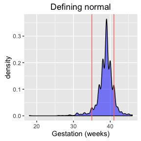

```r
gf_density( ~ combgest + fill:"blue" + alpha:0.5, data = Natality_2014_1k) +
  geom_vline(aes(xintercept = 35, color = "red")) +
  geom_vline(aes(xintercept = 41, color = "red")) +
  ggtitle("Defining normal") +
  xlab("Gestation (weeks)") +
  guides(color = FALSE)
```

### Path Two

“When will my baby arrive?”

Some possibilities:

- Give a general description from the whole population.
- “My” means literally about me. Customize the answer based on individual factors.
- Do pregnancies end after a natural time? How often is the duration determined by artificial factors such as medical intervention? If we separate these out those that end naturally, is the result different? Is it important to give an answer that includes reference to artificial induction of labor.

### Path Three

“What do you mean by ‘normal’?”

Some possibilities:

- The range that most pregnancies last.
  - What does “most” mean?
- The range that healthy pregnancies last.
  - How to define a “healthy pregnancy” based on the data available for each birth.
- it’s of personal interest to at least half of all students at a post-secondary level.
- a setting that is broadly familiar but with many facets that will be new and unfamiliar to many students but where descriptions can easily be found on the internet
- there are many variables, so careful selection is important
- the data can be explored with samples whose size spans several orders of magnitude. Call 1k the study that costs $1000, 10k the study that costs $10,000, and 100k the study that costs $100,000. If you can get an answer with a small study, that’s better!
- simple sounding ideas, such as “health of the baby” or “risk factor,” need to be thoughtfully defined.
- systematically missing data